# Assignment5

Liam

9/30/2019

# Assignment 5. Data Visualization with ggplot2

Submission Instruction. You will need to submit on Blackboard, in the Assignment section, a link to your assignment on your Github Webpage. Following this to create a github webpage and posted a link to your assignment.

This assignment works with the c2015 dataset.

```r
library(tidyverse)
```

```r
library(ggplot2)
library(readxl)
```

1. Clean the data for easy graphing. Do the follows to clean and reduce the size of the data
- Remove all observations that have a cell being either (1) NA, (2)‘Unknown’, (3)‘Not Rep’, or (4)‘Not Reported’
- Remove all observations that have a cell containing either (1)‘Unknown’, (2)‘Not Rep’, or (3)‘Not Reported’. For instance, observations with DRINKING variable being Unknown (Police Reported) will be removed.
- Fix TRAV_SP and AGE (following previous assignments) so that they are both numerics.
- Filter so that there are only drivers in the data

```r
c2015 <- read_excel('c2015.xlsx')
df <- c2015 %>%
  filter_all(~!(.=="Unknown")) %>%
  filter_all(~!(.=="Not Rep")) %>%
  filter_all(~!(.=="Not Reported")) %>%
  filter_all(~!(.==str_detect(.,'Not Rep'))) %>%
  filter_all(~!(.==str_detect(.,'Unknown'))) %>%
  filter_all(~!(.==str_detect(.,'Not Reported'))) %>%
  filter(SEAT_POS=='Front Seat, Left Side') %>%
  mutate(TRAV_SP = as.numeric(substr(TRAV_SP, 1, 3))) %>%
  mutate(AGE = as.numeric(case_when(AGE=="Less than 1"~"0",
                                    TRUE~AGE))) %>%
  mutate(AGE=case_when(is.na(AGE) ~ mean(AGE,na.rm=TRUE),
                       TRUE ~ AGE)) %>%
  mutate(SEX=case_when(is.na(SEX) | SEX=="Not Rep" | SEX=="Unknown" ~ "Female",
                       TRUE~SEX)) %>%
  filter_all(~!is.na(.))
```

2. Use geom_point to plot AGE and TRAV_SP coloring by SEX.

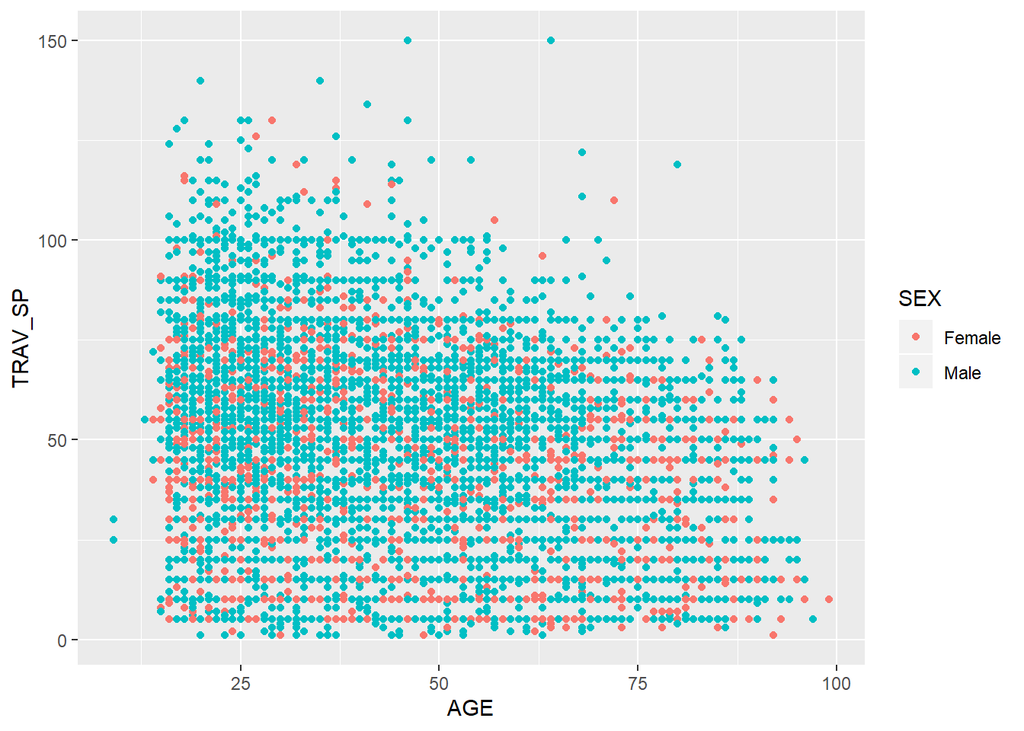

```r
ggplot(df, aes(AGE, TRAV_SP, color=SEX)) +
  geom_point()
```

3. There is overplotting in 2. Overplotting is when many points are duplicated on the graph. Use geom_jitter instead of geom_point for 2. to avoid overplotting.

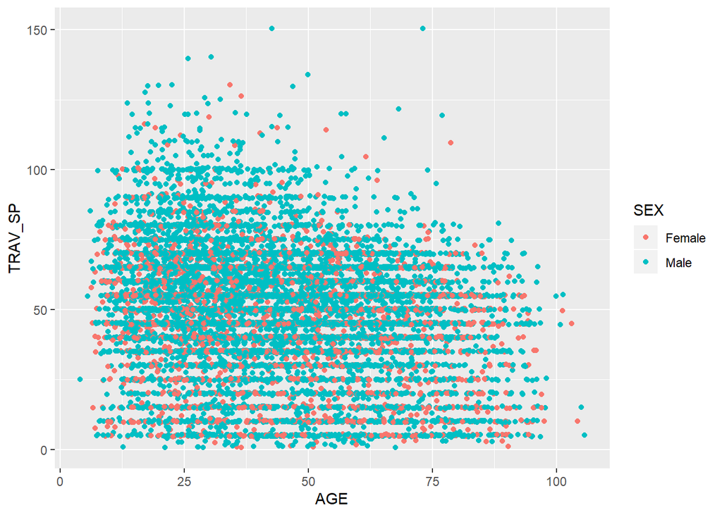

```r
ggplot(df, aes(AGE, TRAV_SP, color=SEX)) +
  geom_jitter(width = 10)
```

4. Plot histograms of AGE, TRAV_SP with bins = 50.

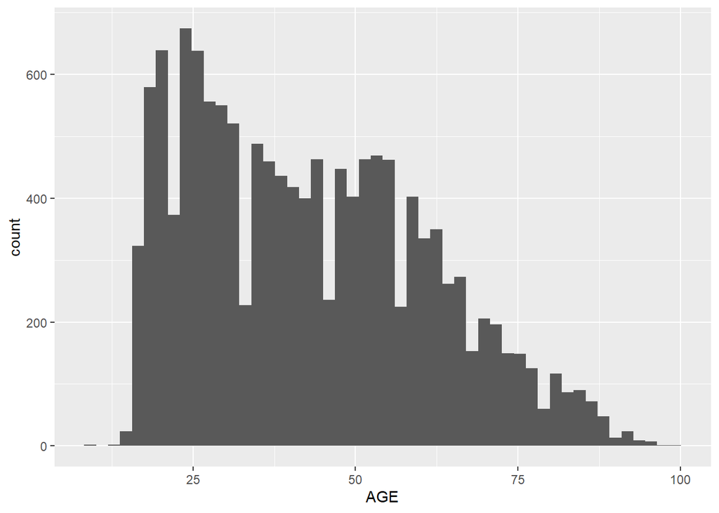

```r
ggplot(df, aes(AGE))+
  geom_histogram(bins = 50)
```

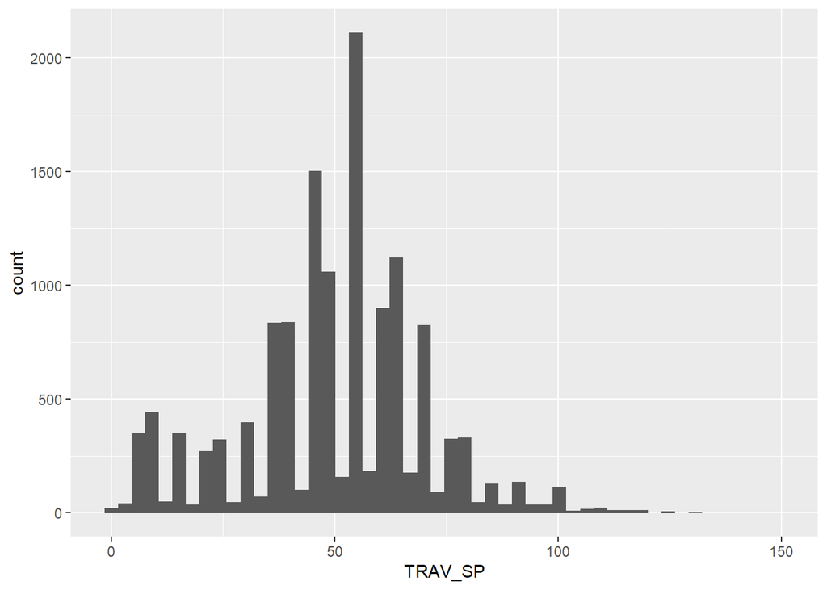

```r
ggplot(df, aes(TRAV_SP))+
  geom_histogram(bins = 50)
```

5. Plot a histogram of AGE coloring (fill) by SEX.

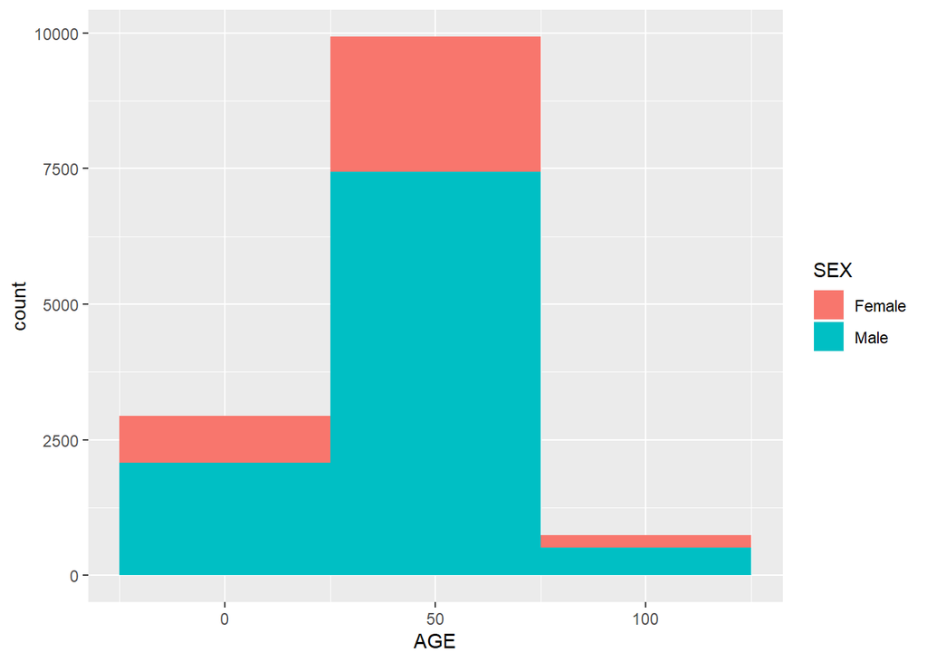

```r
ggplot(df, aes(AGE, fill=SEX))+
  geom_histogram(binwidth = 50)
```

6. Using geom_density to plot estimated densities of AGE colored by SEX.

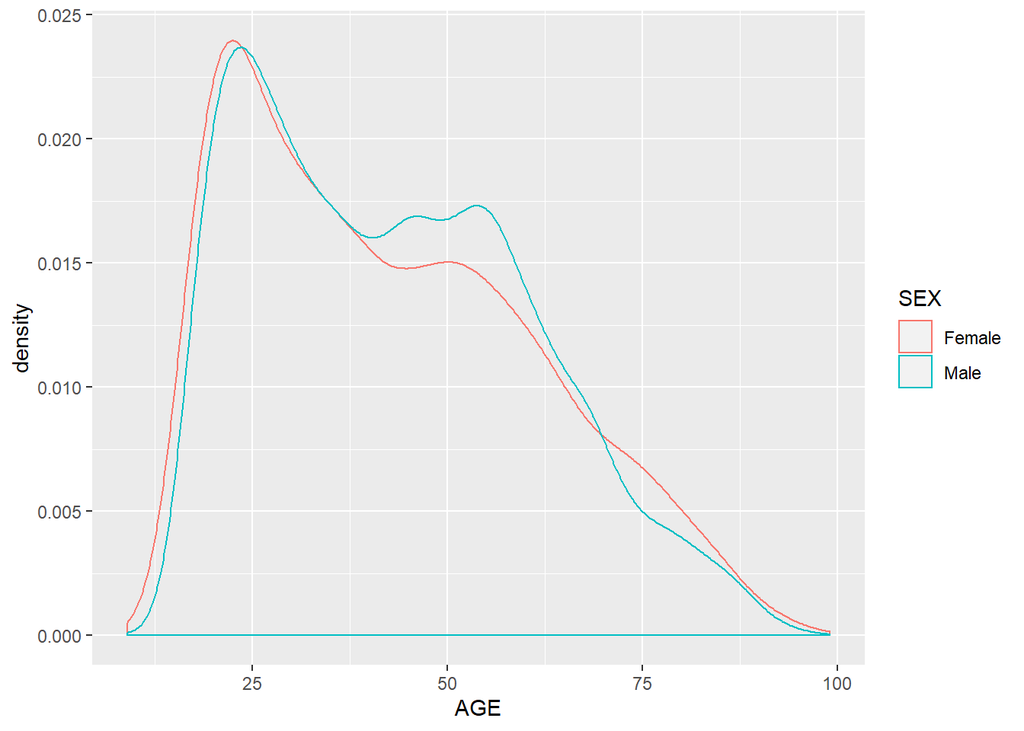

```r
ggplot(df, aes(AGE, color = SEX))+
  geom_density()
```

7. Plot estimated densities of TRAV_SP colored by INJ_SEV.

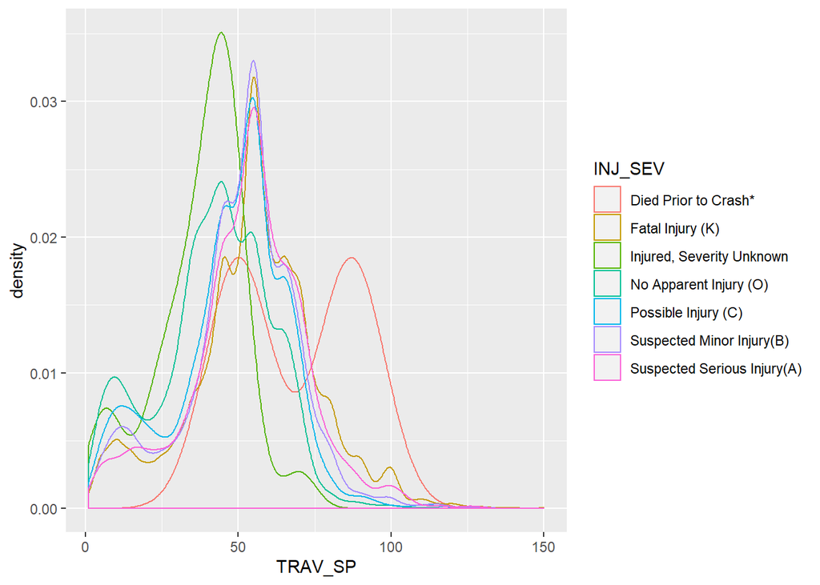

```r
ggplot(df, aes(TRAV_SP, color=INJ_SEV))+
  geom_density()
```

8. Plot estimated densities of TRAV_SP seperated (colored) by weekdays and weekends.

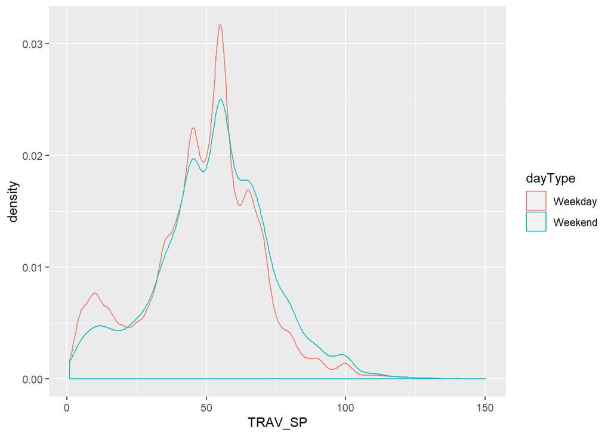

```r
df<-df%>%
    mutate(dayType=case_when(DAY_WEEK=="Saturday" | DAY_WEEK=="Sunday" ~ "Weekend",
                           TRUE~"Weekday"))
ggplot(df, aes(TRAV_SP, color=dayType))+
  geom_density()
```

9. Implement geom_bar on MONTH. Implement geom_bar on MONTH filled by SEX

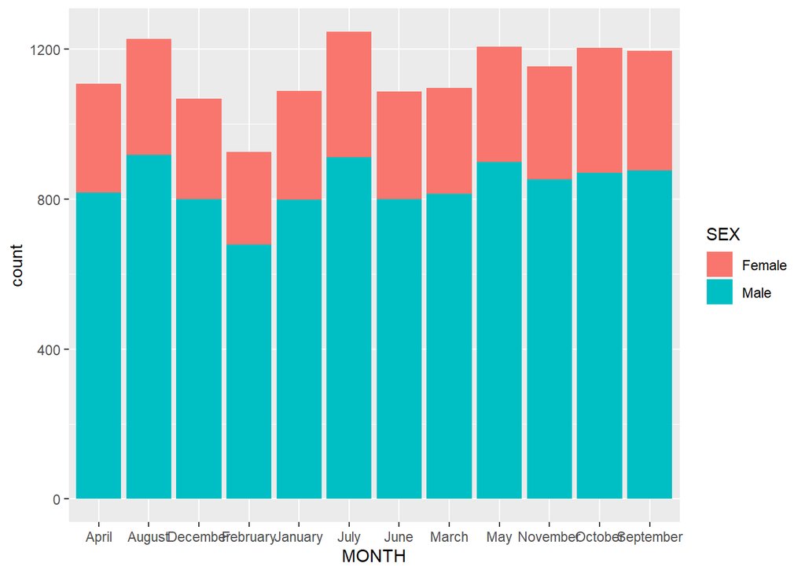

```r
ggplot(df, aes(MONTH, fill=SEX))+
  geom_bar()
```

10. Implement geom_bar on MONTH and SEX with position=‘dodge’

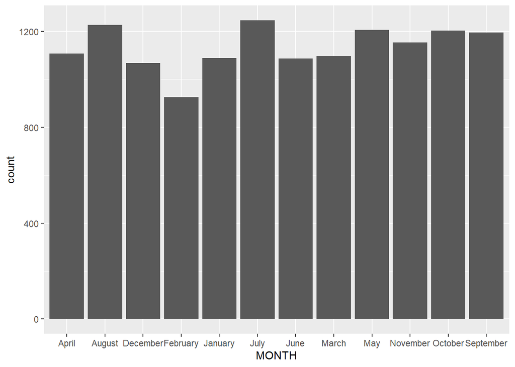

```r
ggplot(df, aes(MONTH))+
  geom_bar(position="dodge")
```

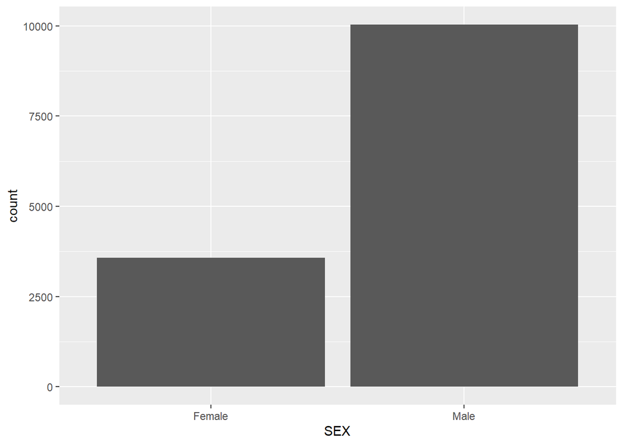

```r
ggplot(df, aes(SEX))+
  geom_bar(position="dodge")
```

11. Plot a bar chart of average speeds in months using geom_col

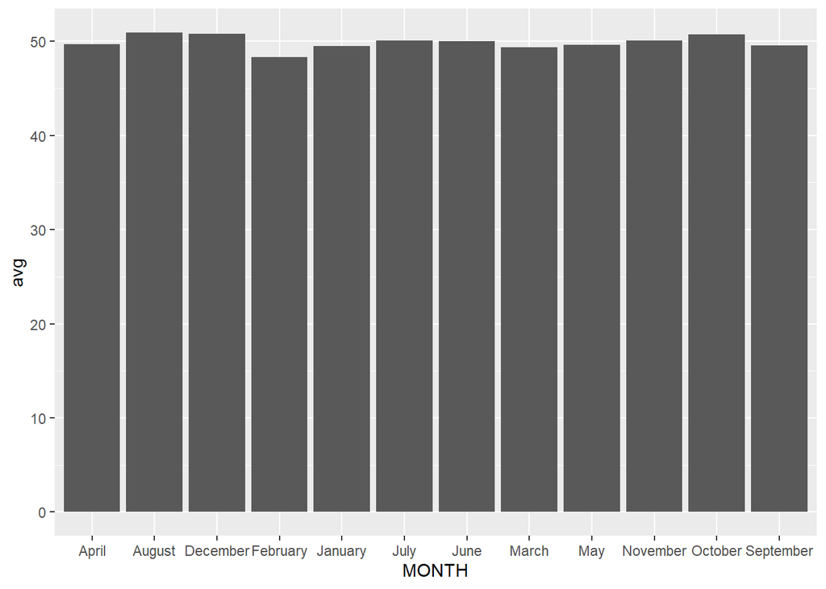

```r
ggplot(df%>%
         group_by(MONTH)%>%
         summarise(avg=mean(TRAV_SP)), aes(x=MONTH, y=avg))+
geom_col()
```

12. Plot a bar chart of average speeds in months using geom_bar

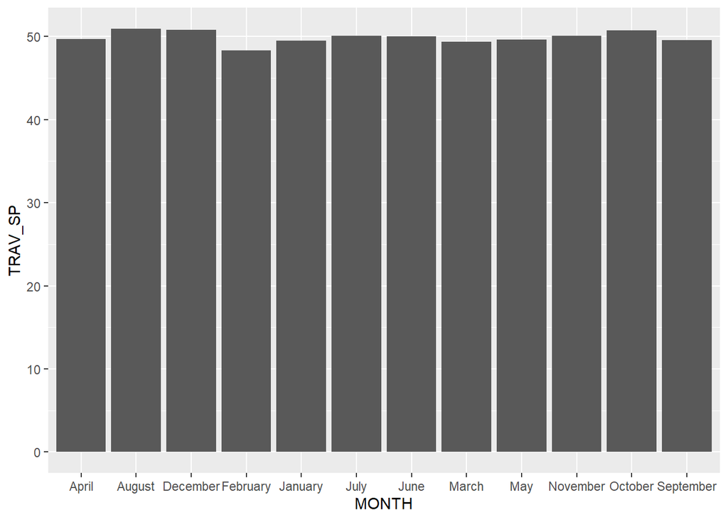

```r
ggplot(df, aes(x=MONTH, y=TRAV_SP))+
  geom_bar(stat = "summary", fun.y = "mean")
```

13. Plot a bar chart of average speeds in months filled by SEX

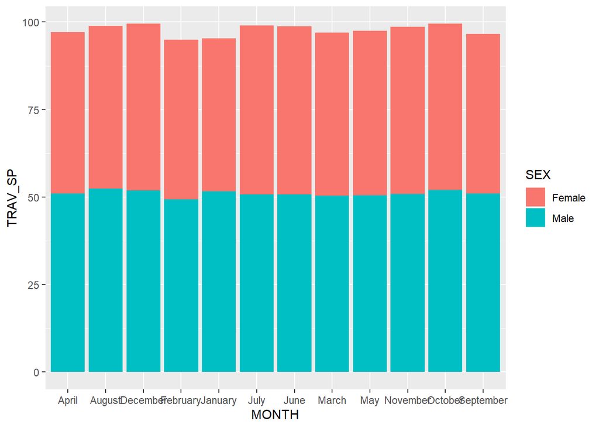

```r
ggplot(df, aes(x=MONTH, y=TRAV_SP, fill=SEX))+
  geom_bar(stat = "summary", fun.y = "mean")
```

14. Plot a bar chart of average speeds in months colored by INJ_SEV

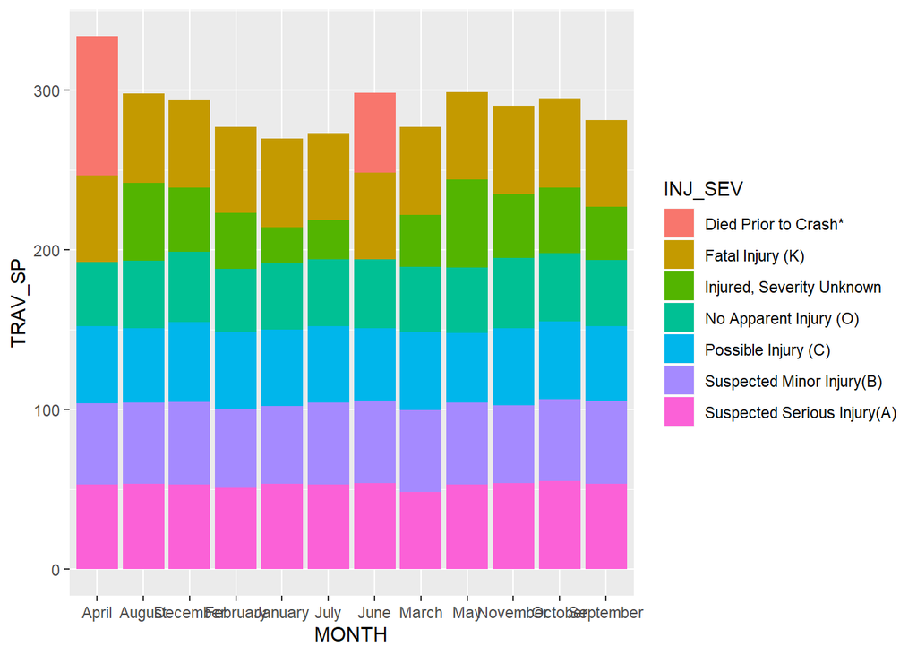

```r
ggplot(df, aes(x=MONTH, y=TRAV_SP, fill=INJ_SEV))+
  geom_bar(stat = "summary", fun.y = "mean")
```

15. Refer to this link to have a similar following plot: - Horizontal axis is for (monthly) average speed - The vertical axis is for months - Color by two colors: one for above overall average speed and the other for below the avarage speed - The speed on the horizontal axis is standardized

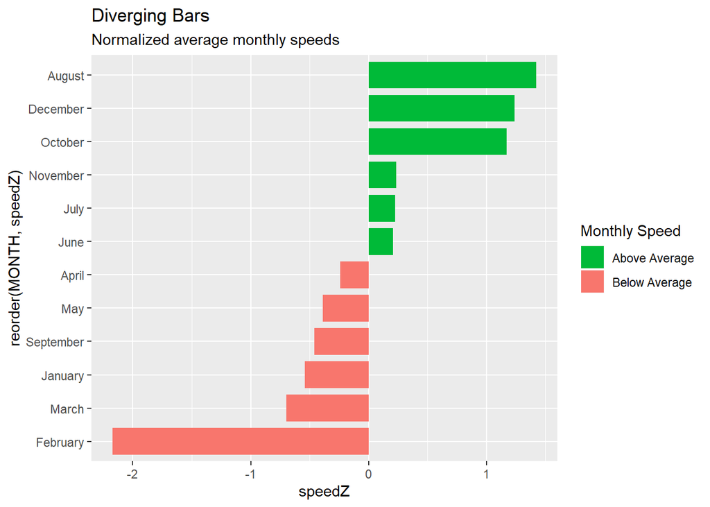

```r
ggplot(df%>%
         group_by(MONTH)%>%
         summarise(avg=mean(TRAV_SP))%>%
         mutate(speedZ=(avg-mean(avg))/sd(avg))%>%
         mutate(spType=case_when(speedZ<0~'Below', TRUE~'Above')),
       aes(x=reorder(MONTH,speedZ), y=speedZ, label=speedZ))+
  geom_bar(stat='identity', aes(fill=spType, width=0.8))+
  scale_fill_manual(name='Monthly Speed',
                    labels = c('Above Average', 'Below Average'),
                    values = c("Above"="#00ba38", "Below"="#f8766d"))+
  labs(subtitle='Normalized average monthly speeds',
       title='Diverging Bars')+
  coord_flip()
```

16. Refer to this link to have a similar following plot: - Horizontal Axis is for mean speed - Vertical Axis is for INJ_SEV - Color by SEX - The numbers of speed are shown in points.

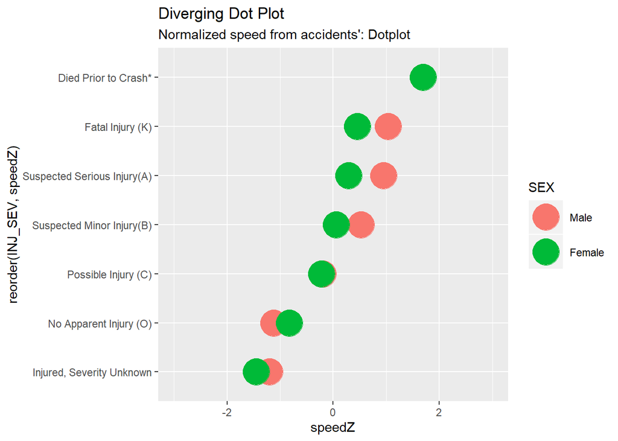

```r
ggplot(df%>%
        group_by(SEX, INJ_SEV)%>%
        summarise(avg=mean(TRAV_SP, na.rm=TRUE))%>%
        mutate(speedZ=(avg-mean(avg, na.rm=TRUE))/sd(avg)),
      aes(x=reorder(INJ_SEV, speedZ), y=speedZ, label=SEX))+
  geom_point(aes(col=SEX), size=10)+
  scale_color_manual(name="SEX",
                     labels = c("Male", "Female"),
                      values = c("Male"="#00ba38", "Female"="#f8766d")) +
  labs(title="Diverging Dot Plot",
  subtitle="Normalized speed from accidents': Dotplot") +
  ylim(-3,3) +
  coord_flip()
```

17. Refer to this link to have a similar following plot: - Horizontal Axis is for speed - Vertical Axis is for DAY - Color by SEX - The should be a invisible vertical line seperating the two sexes.

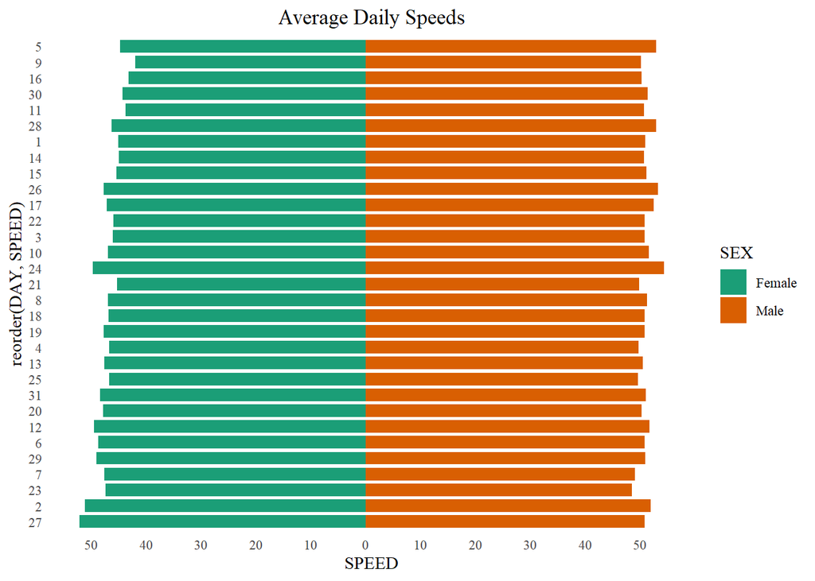

```r
library(ggthemes)
brks <- seq(-70, 70, 10)
lbls = paste0(as.character(c(seq(70, 0, -10), seq(10, 70, 10))))

ggplot(df%>%
         group_by(DAY, SEX)%>%
         summarise(avg=mean(TRAV_SP, na.rm=TRUE)) %>%
         mutate(SPEED=ifelse(SEX=='Female',(avg/-1),avg)),
       aes(x=reorder(DAY, SPEED), y=SPEED, fill=SEX))+
  geom_bar(stat='identity', width=0.8)+
  coord_flip()+
  scale_y_continuous(breaks = brks,   # Breaks
                     labels = lbls) + # Labels
  labs(title="Average Daily Speeds")+
  theme_tufte()+  # Tufte theme from ggfortify
  theme(plot.title = element_text(hjust = .5),
        axis.ticks = element_blank()) +   # Centre plot title
  scale_fill_brewer(palette = "Dark2")
```

18-20. Generate three other interesting graphs from the dataset.

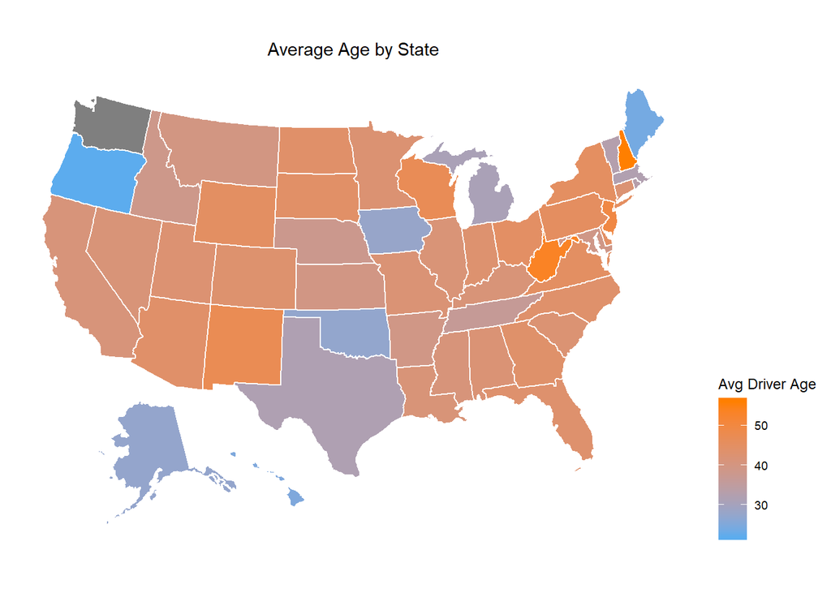

```r
library(usmap)

plot_usmap(data=df %>%
           select(state=STATE, AGE) %>%
           group_by(state) %>%
           summarise(avg=mean(AGE)),
  values = "avg", color = "white") +
  scale_fill_continuous(low = "steelblue2",
                        high = "darkorange1",
                        name = "Avg Driver Age",
                        label = scales::comma) +
  labs(title= "Average Age by State")+
  theme(legend.position = "right",
        plot.title = element_text(hjust = .5))
```

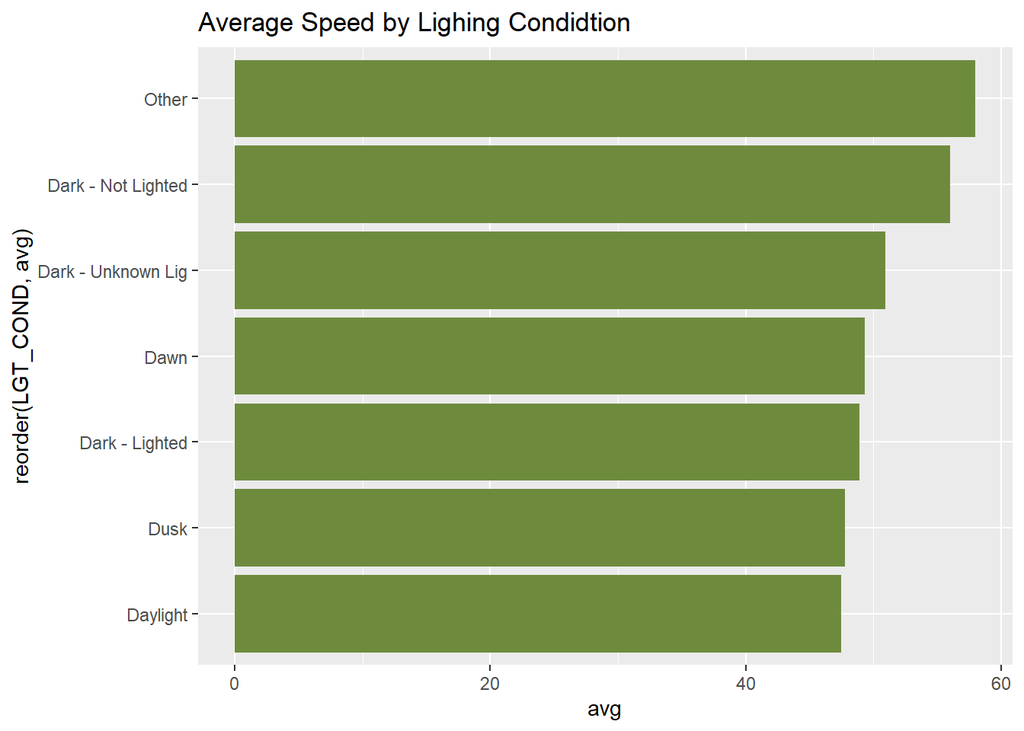

```r
ggplot(df%>%
        group_by(LGT_COND)%>%
        summarise(avg=mean(TRAV_SP)),
       aes(x=reorder(LGT_COND,avg),y=avg))+geom_bar(stat='identity', fill='darkolivegreen4')+
       coord_flip()+
       labs(title="Average Speed by Lighing Condidtion")
```

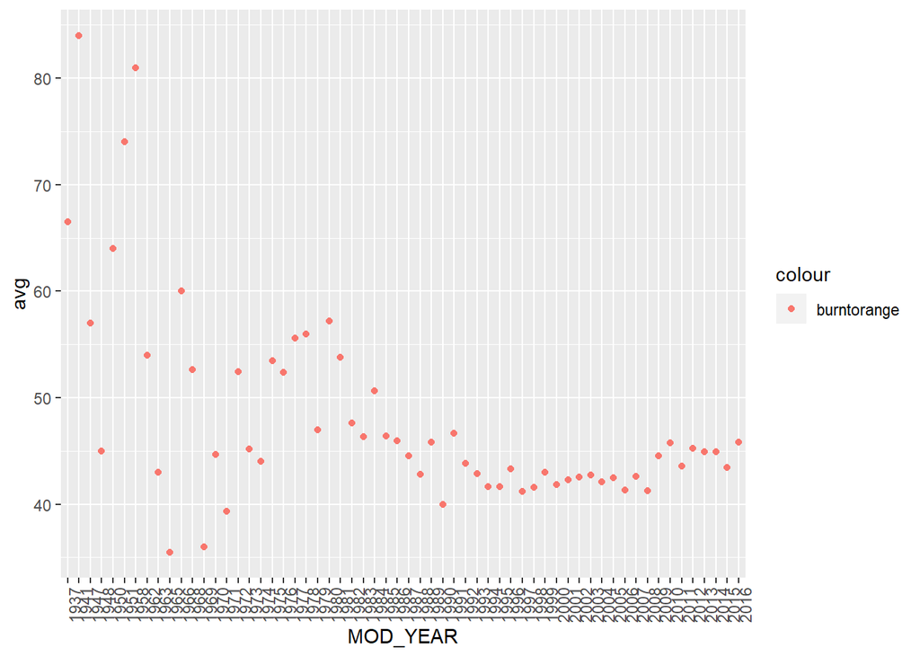

```r
df%>%
        group_by(MOD_YEAR)%>%
        summarise(avg=mean(AGE))%>%
        ggplot(aes(x=MOD_YEAR, y=avg, color='burntorange'))+ geom_point()+ theme(axis.text.x = element_text(angle = 90))
```